# Bio-informatica projecten 2012-2018

Rutger Vos (@rvosa)

27-3-2019

### Samenvatting

> - Gemiddeld is de bioinformaticus op elk moment betrokken bij 8-10 source code projecten
> - De omlooptijd per project is tussen de anderhalf en twee jaar
> - De netto bijdrage aan een project is ongeveer 200-250 uur source code ontwikkeling
> - Berekeningen op basis van 35 projecten tussen 2012-2018 (inclusief)

### Data

Om een indruk te krijgen van het werkproces van de bioinformaticus nemen we alle [source code repositories](https://en.wikipedia.org/wiki/Git) waar de gebruiker rvosa code aan heeft toegevoegd als bijdrage aan onderzoeks- en infrastructuurprojecten van 2012 tot 2018 inclusief, d.w.z. zeven jaar. In deze momentopname laten we de volgende projecten buiten beschouwing:

- repositories voor eigen, onafhankelijk onderzoek
- repositories met lesmateriaal, bijvoorbeeld voor het vak Methods in Biodiversity Analysis of voor workshops
- projecten waarvoor geen source code ontwikkeld hoefde te worden, en die dus geen sporen hebben achter gelaten op GitHub (wat overigens vrijwel nooit voorkomt)

Hier lezen we de data in:

```r
library(lubridate, quietly = T)
# Lees de tabel met projecten
git.df <- read.table(
  file = 'git_projects.tsv',
  header = T,
  sep = "\t"
)

# De kolommen met First_commit en Last_commit zijn data in ISO-8601 format
git.df$First_commit <- ymd(git.df$First_commit)
git.df$Last_commit <- ymd(git.df$Last_commit)
```

Onderstaande tabel laat alle projecten zien, met de volgende kolommen:

- **GitHub_project** - URL voor de project repository
- **First_commit** - eerste bijdrage aan de repository door @rvosa
- **Last_commit** - laatste bijdrage door @rvosa
- **Output** - door het project gegenereerde output (pijltje rechtsboven)

```r
# Weergave
git.df
```

| GitHub_project | First_commit | Last_commit | Output |
| --- | --- | --- | --- |
| http://github.com/naturalis/species-delimitation-data | 2015-10-29 | 2017-03-31 | 10.1111/1755-0998.12557 |
| http://github.com/naturalis/nepenthes | 2013-07-08 | 2014-01-09 | 10.1111/ddi.12382 |
| http://github.com/naturalis/orchids | 2012-03-16 | 2016-01-08 | 10.1186/s12862-017-0938-7 |
| http://github.com/naturalis/cobra | 2012-03-05 | 2014-05-15 | 10.1073/pnas.1314702110 |
| http://github.com/naturalis/ngs-workflows | 2012-07-30 | 2012-09-14 | documentatie |
| http://github.com/naturalis/brahms-digi-webapp | 2012-09-21 | 2013-01-27 | selectie tomaten herbariumsheets |
| http://github.com/naturalis/fastq-simple-tools | 2012-12-20 | 2013-11-19 | IonTorrent/FASTQ utility scripts |
| http://github.com/naturalis/nepenthes-3dpca | 2013-09-13 | 2014-05-19 | Galaxy tools 3D scans Nepenthes |
| http://github.com/naturalis/geogenodist | 2014-05-01 | 2014-05-20 | GBIF/BOLD utility scripts |
| http://github.com/naturalis/ai-fann-evolving | 2014-02-04 | 2014-09-16 | 10.1101/070904 |

[output cut: 25 more lines]

### Omlooptijd

Wat is de verdeling van de omlooptijd van deze projecten? We rekenen dit van de eerste tot de laatste *commit* operatie waarin een wijziging aan de source code van het project is toegevoegd door @rvosa. Dat is dus een lage schatting omdat projecten beginnen voor de eerste commit (planning, overleg) en vaak eindigen ver na de laatste, bijvoorbeeld omdat er dan nog analyses worden gedraaid en manuscripten worden geschreven.

```r
# Hier berekenen we de omlooptijd
git.df$Duration <- vector( mode = "integer", length = nrow(git.df) )
for ( row in 1:nrow(git.df) ) {

  # De omlooptijd is 'inclusief', dus + 1
  git.df[row,'Duration'] <-
    ( git.df[row,'Last_commit'] - git.df[row,'First_commit'] ) + 1
}

# Bereken de summary statistics en maak een histogram
duration.summ.stats <- summary(git.df$Duration)
duration.summ.stats
```

```
##    Min. 1st Qu.  Median    Mean 3rd Qu.    Max.
##    20.0   188.0   497.0   637.2   886.5  1964.0
```

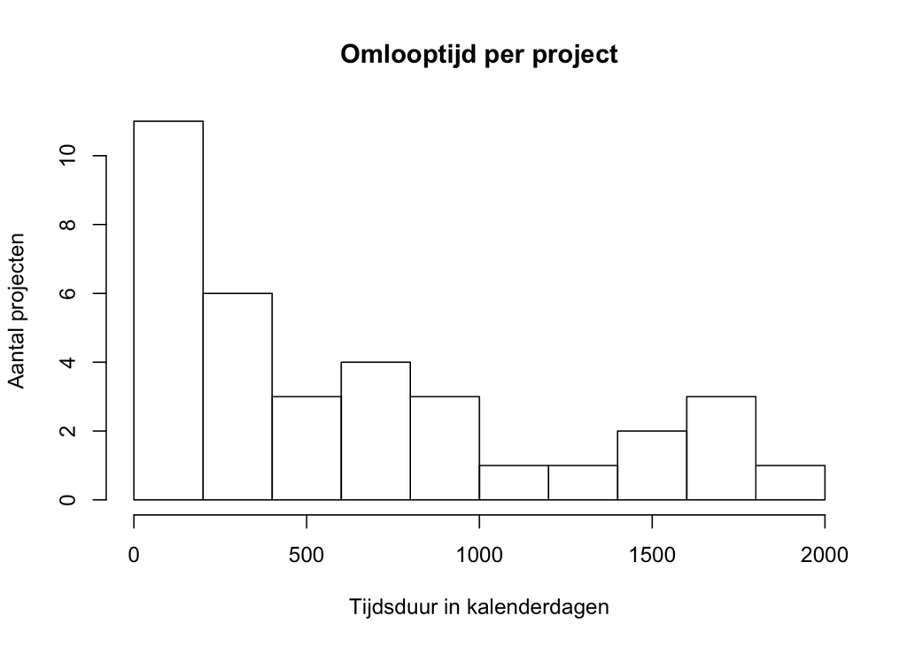

```r
hist(
  git.df$Duration,
  main = "Omlooptijd per project",
  ylab = "Aantal projecten",
  xlab = "Tijdsduur in kalenderdagen"
)
```

De duur in kalenderdagen is dus tussen de anderhalf en twee jaar (mean/median). Het kortste project had een omlooptijd van 20 dagen, het langste van 1964 dagen, oftewel meer dan vijf jaar. De langst lopende projecten zijn die waarbij infrastructuur is ontwikkeld die vervolgens moet worden onderhouden. De top 5 bestaat daardoor uit:

1. [supersmart](http://www.supersmart-project.org) - pijplijn
2. wgs2ncbi - Galaxy tool
3. [monophylizer](http://monophylizer.naturalis.nl) - web service
4. HTS-barcode-checker - Galaxy tool
5. [imgpheno](http://plakvallen.naturalis.nl/) - web service

### Gemiddelde bezetting

Hoe veel projecten lopen er tegelijkertijd? We gaan hier van de eerste tot de laatste dag in de data set en bekijken voor elke dag welke projecten er op dat moment actief zijn, d.w.z. dat we voor dat project in de periode tussen de eerste en de laatste commit zitten:

```r
# Datum van de allereerste activiteit
start.date <- min(git.df$First_commit)

# Datum van de allerlaatste activiteit
end.date <- max(git.df$Last_commit)

# Duur (in dagen) van eerste tot laatste
range.date <- end.date - start.date

# Vector met, van dag tot dag, de bezettingsgraad
concurrency <- vector( mode = "integer", length = range.date[[1]])
for ( i in 1:range.date[[1]] ) {

  # Bereken datum op dit punt in de loop
  day.date <- start.date + i

  # Ga alle projecten langs
  for ( row in 1:nrow(git.df) ) {
    proj.interval <- interval(
      git.df[row,'First_commit'],
      git.df[row,'Last_commit']
    )
    if ( day.date %within% proj.interval ) {
      concurrency[i] <- concurrency[i] + 1
    }
  }
}
concurrency.summ.stats <- summary(concurrency)
concurrency.summ.stats
```

```
##    Min. 1st Qu.  Median    Mean 3rd Qu.    Max.
##   1.000   5.000  10.000   8.822  13.000  16.000
```

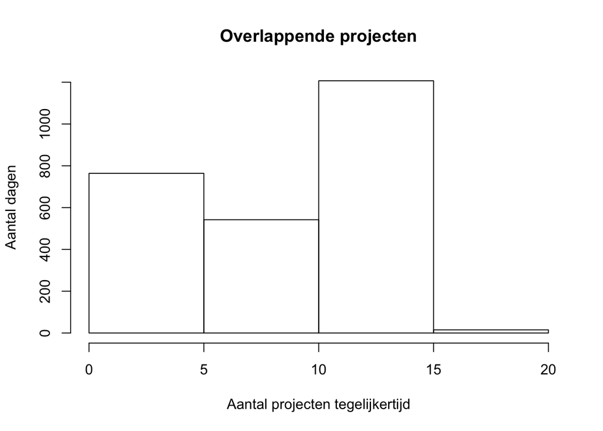

```r
hist(
  concurrency,
  breaks = 5,
  xlab = "Aantal projecten tegelijkertijd",
  ylab = "Aantal dagen",
  main = "Overlappende projecten"
)
```

### Gemiddelde duur in uren per project

Om op een tijdsduur in uren per project uit te komen nemen we de volgende stappen, op basis van de eerder berekende ‘duration’ *D*

1. kantoordagen *K* = *D* * 5/7 (maandag t/m vrijdag)
2. werkdagen *W* = *K* * 240/260 (20 dagen verlof per jaar)
3. bioinformatica dagen *B* = *W* * 7/10 (exclusief andere institutionele activiteiten 20% en onderwijs 10%)
4. per project *P* = *B* * 1/8.xx (gemiddelde bezettingsgraad zoals berekend)
5. uren *U* = *P* * 8 (uur per dag)

Voor de berekening in stap 3 beschouwen we als “Andere institutionele activiteiten”, een dag in de week, bijvoorbeeld:

- deelname aan stuurgroepen (NBA, DL, RDM)
- onderhoud infra exclusief source code ontwikkeling (TreeBASE, OpenStack, high-mem node)
- overleg onderzoeksgroep, overleg andere interne gremia
- aanvragen (mee)schrijven
- interne rapportages

We beschouwen als “Onderwijs”, een halve dag in de week, bijvoorbeeld:

- (gast)colleges voorbereiden en geven
- overleg/begeleiding van stagiaires
- verslagen nakijken
- studentenpresentaties bijwonen

```r
git.df$Hours <- vector( mode = "double", length = nrow(git.df) )
for ( row in 1:nrow(git.df) ) {
  K <- git.df[row, 'Duration'] * (5/7)
  W <- K * (240/260)
  B <- W * (7/10)
  P <- B * (1/concurrency.summ.stats[[4]])
  U <- P * 8
  git.df[row, 'Hours'] <- U
  rm(K,W,B,P,U)
}
summary(git.df$Hours)
```

```
##    Min. 1st Qu.  Median    Mean 3rd Qu.    Max.
##   8.371  78.684 208.012 266.702 371.031 822.001
```

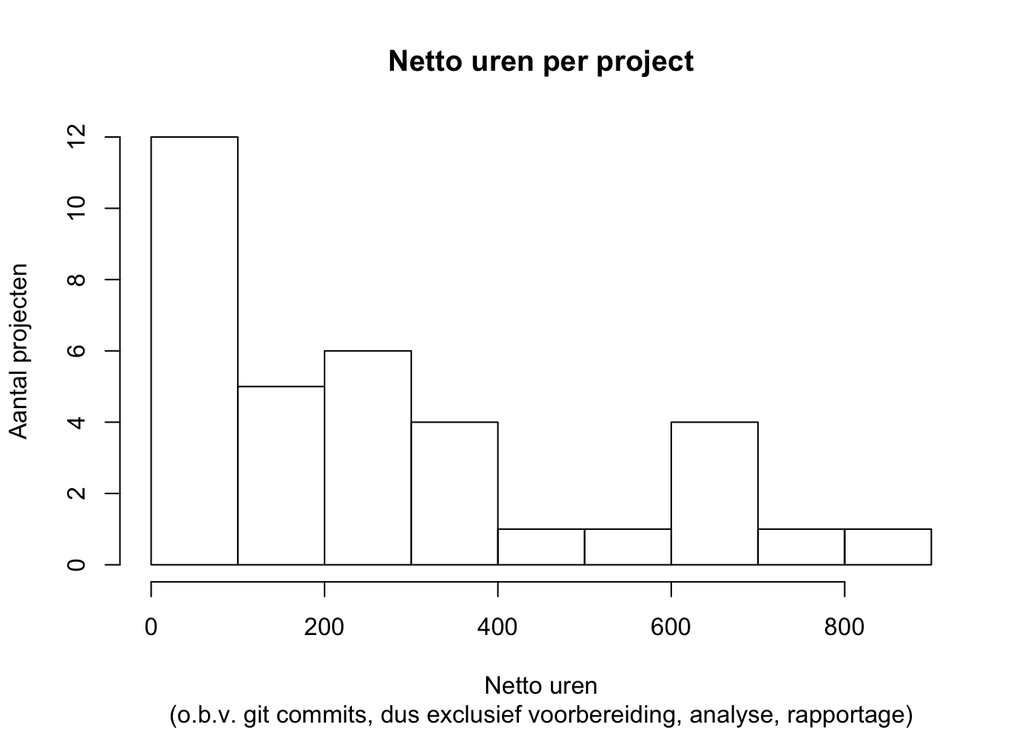

```r
hist(
  git.df$Hours,
  main = 'Netto uren per project',
  sub = '(o.b.v. git commits, dus exclusief voorbereiding, analyse, rapportage)',
  ylab = 'Aantal projecten',
  xlab = 'Netto uren'
)
```

### Conclusies / inzichten

- ‘Korte’ projecten, zoals het [koppelen van Brahms data aan gedigitaliseerde herbariumsheets](https://github.com/naturalis/brahms-digi-webapp), of het ontwikkelen van [Nepenthes fylogenieen](https://github.com/naturalis/nepenthes) lopen langer door dan van tevoren door onderzoekers ingeschat. Dit vanwege ‘nazorg’, bijvoorbeeld in het meeschrijven aan manuscripten inclusief revisies, of in het opnieuw uitvoeren van analyses met andere parameterisatie of andere input data. **Gezien de in het verleden behaalde resultaten zijn door onderzoekers in de huidige ronde gemaakte inschattingen daarom waarschijnlijk te optimistisch.**
- De status van ‘lange’ projecten - zijn deze afgerond? - wordt niet helder gecommuniceerd door de PI’s en slepen dus voort. Voorbeelden zijn het [tomatenproject](http://github.com/naturalis/tomatogenome) en de [exoomdata mensapen](http://github.com/naturalis/apexomes). In de huidige berekeningen is uitgegaan van de laatste bijdrage van @rvosa aan deze projecten en zijn deze dus per definitie ‘af’ - want er is altijd een meest recente *commit* - maar er is nog geen aanwijsbare output. Zonder externe output middels een publicatie waarbij alle data op publieke plekken zijn gezet, hoopt de data onder embargo op, met de permanente mogelijkheid dat die dus weer vele jaren na dato moet worden opgegraven (voorbeeld van deze week: waar is de genome assembly voor *Gonioctena quinquepunctata* die in 2014 op de T-7500 in het lab is uitgevoerd?) **Om zulke chronische ophoping te voorkomen moeten nieuwe aanvragen een duidelijk einde hebben voor wat betreft alle uitkomsten (inclusief research data, dus).**
- Projecten die infrastructuur opleveren, zoals databases, Galaxy tools, of web services, vereisen onderhoud. Gebruikers rapporteren bugs of verzoeken om extra functionaliteit; upgrades worden na verloop van tijd noodzakelijk, bijvoorbeeld vanwege ICT security of nieuwe data releases. Hierdoor zijn deze projecten nooit ‘af’ (in principe van toepassing op HTS-Barcode-Checker, Monophylizer, TreeBASE, WGS2NCBI, plakvallen). Als we iets bouwen puur om formeel aan de eisen van projecten te voldoen (zoals biovel-nbc) dan blijven deze resultaten [niet in de lucht](https://en.wikipedia.org/wiki/Software_rot). **Bij de aanvraag van nieuwe, herbruikbare infrastructuur moet dus ook met onderhoud (of overdracht) rekening gehouden worden.**

Gezien:

1. de gemiddelde omlooptijd per project (1,5-2 jaar),
2. de gemiddelde bezettingsgraad (8-10 projecten tegelijkertijd),
3. de beschikbare capaciteit (1,5FTE totaal),
4. de huidige projectenlijst (5 projecten voorgesteld per maart 2019), en
5. de lopende projecten van @rvosa:
   - publicatie FormicID
   - publicatie wgs2ncbi
   - afronding hosting [TreeBASE](http://treebase.org)
   - onderhoud, functionaliteit [plakvallen](http://plakvallen.naturalis.nl)
   - onderhoud, updates HTS-barcode-checker

Kunnen er nog 1-2 rondjes met CfP’s gehouden worden via SWO3 in de komende kwartalen: we zitten qua expliciet geformuleerde en aangevraagde projecten nog niet aan de gemiddelde capaciteit in vergelijking tot de afgelopen jaren. Echter, als we op deze manier meer projecten gaan toevoegen dan moeten er ook beslissingen worden genomen over de status van nog lopende onderzoeksprojecten, met name de tomaten en de exoomdata, en de onderhoud van lopende infrastructuurprojecten, bijvoorbeeld in relatie tot de eisen vanuit ICT qua upgrades.